# e_comm_sales

How You Can Perform This Task?

1️⃣ Find and Download an E-Commerce Dataset

Visit Kaggle and search for "E-commerce sales data". Select a dataset that includes fields like Order ID, Date, Customer ID, Product, Quantity, and Revenue. Download the dataset in CSV format and store it in a working directory.

2️⃣ Load the Dataset in Python

Open the CSV file using a data analysis tool like Pandas in Python or Excel. Display the first few rows to get an overview of the dataset structure.

3️⃣ Explore the Dataset Structure

Check the total number of rows and columns to understand dataset size. Identify different data types (e.g., numerical, categorical, date fields). Examine if key fields like Order Date, Revenue, and Customer ID are present.

4️⃣ Identify Missing Values and Duplicates

Scan the dataset for missing or null values in important columns. Identify duplicate transactions that may impact the accuracy of analysis. Note down any inconsistencies in formatting (e.g., incorrect date formats).

5️⃣ Identify Key Columns for Analysis

Focus on sales and revenue-related columns that will be used in trend analysis. Look for customer segmentation features like purchase frequency and spending behavior. Note down any geographical information if available, to analyze sales distribution by region.

6️⃣ Document Observations

Write a short summary of key insights about the dataset. Note any data quality issues that need to be addressed in the cleaning process. Save the dataset in a structured format for further analysis.

```python
import pandas as pd
import numpy as np
import seaborn as sns
```

```python
df = pd.read_csv('ecommerce_sales_data.csv')
```

```python
df.head()
```

|  | Order ID | Product Name | Category | Price | Quantity | Total Sales | Customer ID | Customer Age | Customer Gender | Purchase Date | Purchase Time |
| --- | --- | --- | --- | --- | --- | --- | --- | --- | --- | --- | --- |
| 0 | 261e3740-c0e9-42b1-bf87-881ac950fa3a | audience | Home & Garden | 766.85 | 4 | 3067.40 | 81af1248-afff-46ee-a091-81cf33d0d957 | 39 | Male | 25/05/2024 | 6:28:14 |
| 1 | 0b332b34-46dc-4eaf-a808-fec7e97ffbc6 | such | Clothing | 331.42 | 4 | 1325.68 | f3f3f4ac-7ad0-4362-9134-383096d16ac8 | 21 | Male | 04/05/2024 | 19:37:36 |
| 2 | 432e0b36-724d-4521-85ae-f66db8af8105 | read | Clothing | 708.10 | 10 | 7081.00 | c4fc4269-3c1d-4b6b-ad23-d437c328d63f | 27 | Female | 07/05/2024 | 17:54:42 |
| 3 | ca20fb08-5c65-43b8-9577-3fa49913f93b | skill | Electronics | 774.09 | 2 | 1548.18 | 578e2d1a-d92a-449d-8eeb-b704110b2975 | 51 | Female | 23/05/2024 | 22:31:43 |
| 4 | 1dce189c-8c60-455f-a6f2-69bb2cb71539 | cold | Electronics | 397.22 | 1 | 397.22 | dc6ed196-0874-46bd-bbb9-c5534f619349 | 45 | Female | 15/03/2024 | 3:08:25 |

```python
df.info()
```

```
<class 'pandas.core.frame.DataFrame'>
RangeIndex: 100000 entries, 0 to 99999
Data columns (total 11 columns):
 #   Column           Non-Null Count   Dtype
---  ------           --------------   -----
 0   Order ID         100000 non-null  object
 1   Product Name     100000 non-null  object
 2   Category         100000 non-null  object
 3   Price            100000 non-null  float64
 4   Quantity         100000 non-null  int64
 5   Total Sales      100000 non-null  float64
 6   Customer ID      100000 non-null  object
 7   Customer Age     100000 non-null  int64
 8   Customer Gender  100000 non-null  object
 9   Purchase Date    100000 non-null  object
 10  Purchase Time    100000 non-null  object
dtypes: float64(2), int64(2), object(7)
memory usage: 8.4+ MB
```

```python
df.isnull().sum()
```

```
Order ID           0
Product Name       0
Category           0
Price              0
Quantity           0
Total Sales        0
Customer ID        0
Customer Age       0
Customer Gender    0
Purchase Date      0
Purchase Time      0
dtype: int64
```

```python
df['Customer Age'].mean().round(0)
```

```
np.float64(44.0)
```

```python
#select "Customer Gender" , Price from Ecommerce_Sales_Data group by "Customer Gender";
```

```python
df.groupby('Customer Gender').agg({'Price': ['sum']})
```

| Customer Gender | Price sum |
| --- | --- |
| Female | 27525869.91 |
| Male | 27529166.43 |

select Category , sum("Total Sales") , min("Total Sales") , max("Total Sales") , count("Quantity") , min("Quantity") , max("Quantity") from Ecommerce_Sales_Data group by Category;

```python
df.groupby('Category').agg({'Total Sales': ['sum','min', 'max'],'Quantity': ['count','min','max']})
```

| Category | Total Sales sum | Total Sales min | Total Sales max | Quantity count | Quantity min | Quantity max |
| --- | --- | --- | --- | --- | --- | --- |
| Books | 60820086.17 | 100.07 | 9993.1 | 20027 | 1 | 10 |
| Clothing | 61071489.36 | 100.46 | 9998.7 | 20144 | 1 | 10 |
| Electronics | 59955937.12 | 100.28 | 9996.2 | 19899 | 1 | 10 |
| Home & Garden | 60670371.57 | 100.05 | 9999.4 | 20074 | 1 | 10 |
| Toys | 60274785.96 | 100.14 | 9999.1 | 19856 | 1 | 10 |

```python
df.groupby('Product Name').agg({'Total Sales': ['sum','min', 'max'],'Quantity': ['min','mean','max']}).round()
```

| Product Name | Total Sales sum | Total Sales min | Total Sales max | Quantity min | Quantity mean | Quantity max |
| --- | --- | --- | --- | --- | --- | --- |
| American | 319950.0 | 162.0 | 9041.0 | 1 | 6.0 | 10 |
| Congress | 324787.0 | 232.0 | 8518.0 | 1 | 6.0 | 10 |
| Democrat | 329814.0 | 176.0 | 9958.0 | 1 | 6.0 | 10 |
| I | 300771.0 | 123.0 | 9693.0 | 1 | 5.0 | 10 |
| Mr | 328837.0 | 209.0 | 8940.0 | 1 | 6.0 | 10 |
| ... | ... | ... | ... | ... | ... | ... |
| yet | 271084.0 | 122.0 | 8927.0 | 1 | 5.0 | 10 |
| you | 237860.0 | 171.0 | 7980.0 | 1 | 5.0 | 10 |
| young | 353272.0 | 103.0 | 9634.0 | 1 | 5.0 | 10 |
| your | 314417.0 | 121.0 | 9445.0 | 1 | 6.0 | 10 |
| yourself | 383544.0 | 166.0 | 9393.0 | 1 | 6.0 | 10 |

971 rows × 6 columns

```python
#select Category, round(stddev(Price)) from Ecommerce_Sales_Data group by Category;

price_standard_derivation = df.groupby('Category')['Price'].std().round()
print(price_standard_derivation)
```

```
Category
Books            261.0
Clothing         260.0
Electronics      262.0
Home & Garden    260.0
Toys             260.0
Name: Price, dtype: float64
```

```python
#select Category, variance(Price) from Ecommerce_Sales_Data group by Category;

price_variance = df.groupby('Category')['Price'].var()
print(price_variance)
```

```
Category
Books            67921.327092
Clothing         67390.373496
Electronics      68725.523268
Home & Garden    67635.136890
Toys             67788.494822
Name: Price, dtype: float64
```

```python
#select Category, round(AVG(Price), 2), round(VAR_SAMP(Price), 2),round(STDDEV_SAMP(Price), 2) from Ecommerce_Sales_Data group by Category;

price_stats = df.groupby('Category')['Price'].agg(['mean', 'var', 'std']).round(2)
print(price_stats)
```

```
                 mean       var     std
Category
Books          552.48  67921.33  260.62
Clothing       552.53  67390.37  259.60
Electronics    549.60  68725.52  262.16
Home & Garden  548.46  67635.14  260.07
Toys           549.66  67788.49  260.36
```

```python
# Check the columns of your dataset
print(df.columns)
```

```
Index(['Order ID', 'Product Name', 'Category', 'Price', 'Quantity',
       'Total Sales', 'Customer ID', 'Customer Age', 'Customer Gender',
       'Purchase Date', 'Purchase Time'],
      dtype='object')
```

```python
import pandas as pd

# Assuming your dataset is loaded into a DataFrame called 'df'
df['Purchase Date'] = pd.to_datetime(df['Purchase Date'])  # Ensure 'Purchase Date' is in datetime format

# Trend analysis - Revenue over time (daily or monthly)
# Group by date and sum total sales for daily trend analysis
daily_sales = df.groupby(df['Purchase Date'].dt.date)['Total Sales'].sum()

# For monthly trend analysis
monthly_sales = df.groupby(df['Purchase Date'].dt.to_period('M'))['Total Sales'].sum()

# Customer segmentation - Purchase frequency and spending behavior
customer_segmentation = df.groupby('Customer ID').agg(
    purchase_frequency=('Total Sales', 'count'),  # Number of purchases per customer
    total_spending=('Total Sales', 'sum')  # Total spending per customer
).reset_index()

# Check outputs
print(daily_sales.head())
print(monthly_sales.head())
print(customer_segmentation.head())
```

```
Purchase Date
2024-01-01    2218509.60
2024-01-02    1865463.46
2024-01-03    1866468.14
2024-01-04    2021443.53
2024-01-05    1807091.30
Name: Total Sales, dtype: float64
Purchase Date
2024-01    59778158.05
2024-02    56363072.63
2024-03    60750883.75
2024-04    58328508.11
2024-05    59660466.02
Freq: M, Name: Total Sales, dtype: float64
                            Customer ID  purchase_frequency  total_spending
0  000300b1-0eaf-4ace-9aaf-067f2e4f8ce1                   1         2514.10
1  00041160-9942-455f-833b-20e26dcd16de                   1          799.22
2  00052fdc-36b6-49a2-b629-aab5e52f5f19                   1          637.03
3  00059c43-6da9-4d68-837e-08adf003a2e4                   1         2330.44
4  00065815-8092-4cc6-9fb4-1b2cbdbebe51                   1         2479.20
```

```python
# Check the first few rows of the dataset for any potential geographical data in columns like 'Product Name' or 'Category'
print(df[['Product Name', 'Category']].head())

# Example: If the product name contains location data, you can extract it (adjust based on the actual data structure)
# For instance, let's assume some product names have city names, e.g., 'Laptop_NewYork'
df['Region'] = df['Product Name'].str.extract(r'([A-Za-z]+)')  # Adjust the regex based on your data

# Check the new 'Region' column
print(df['Region'].head())

# Now you can analyze sales by region if the 'Region' column is populated
geographical_sales = df.groupby('Region')['Total Sales'].sum().reset_index()

# Display the results
print(geographical_sales.head())
```

```
  Product Name       Category
0     audience  Home & Garden
1         such       Clothing
2         read       Clothing
3        skill    Electronics
4         cold    Electronics
0    audience
1        such
2        read
3       skill
4        cold
Name: Region, dtype: object
     Region  Total Sales
0  American    319950.33
1  Congress    324787.29
2  Democrat    329813.61
3         I    300771.39
4        Mr    328836.92
```

```python
# Assuming your dataset is loaded into a DataFrame called 'df'
# Ensure 'Purchase Date' is in datetime format
df['Purchase Date'] = pd.to_datetime(df['Purchase Date'])

# 1. Revenue over time (daily)
# Group by the 'Purchase Date' and sum the 'Total Sales' to get daily revenue
daily_revenue = df.groupby(df['Purchase Date'].dt.date)['Total Sales'].sum()

# Display the daily revenue
print("Daily Revenue:")
print(daily_revenue.head())

# 2. Revenue over time (monthly)
# Group by month and sum the 'Total Sales' to get monthly revenue
monthly_revenue = df.groupby(df['Purchase Date'].dt.to_period('M'))['Total Sales'].sum()

# Display the monthly revenue
print("\nMonthly Revenue:")
print(monthly_revenue.head())

# 3. Additional Revenue Trend: Total Revenue Over All Time Periods
total_revenue = df['Total Sales'].sum()

# Display total revenue
print(f"\nTotal Revenue: {total_revenue}")
```

```
Daily Revenue:
Purchase Date
2024-01-01    2218509.60
2024-01-02    1865463.46
2024-01-03    1866468.14
2024-01-04    2021443.53
2024-01-05    1807091.30
Name: Total Sales, dtype: float64

Monthly Revenue:
Purchase Date
2024-01    59778158.05
2024-02    56363072.63
2024-03    60750883.75
2024-04    58328508.11
2024-05    59660466.02
Freq: M, Name: Total Sales, dtype: float64

Total Revenue: 302792670.18
```

```python
import pandas as pd

# Assuming your dataset is loaded into a DataFrame called 'df'

# Check for duplicate records based on 'Order ID' and 'Customer ID'
duplicates = df[df.duplicated(subset=['Order ID', 'Customer ID'], keep=False)]

# Display duplicate records (if any)
print("Duplicate Transactions:")
print(duplicates)

# Remove duplicate records based on 'Order ID' and 'Customer ID'
df_cleaned = df.drop_duplicates(subset=['Order ID', 'Customer ID'], keep='first')  # Keep the first occurrence

# Verify that duplicates are removed
print("\nData After Removing Duplicates:")
print(df_cleaned.head())

# Optionally, check if there are any remaining duplicates after removal
remaining_duplicates = df_cleaned[df_cleaned.duplicated(subset=['Order ID', 'Customer ID'], keep=False)]
print(f"\nRemaining Duplicates: {remaining_duplicates.shape[0]}")

# Now df_cleaned contains the data without duplicate transactions
```

```
Duplicate Transactions:
Empty DataFrame
Columns: [Order ID, Product Name, Category, Price, Quantity, Total Sales, Customer ID, Customer Age, Customer Gender, Purchase Date, Purchase Time, Region]
Index: []

Data After Removing Duplicates:
                               Order ID Product Name       Category   Price  \
0  261e3740-c0e9-42b1-bf87-881ac950fa3a     audience  Home & Garden  766.85
1  0b332b34-46dc-4eaf-a808-fec7e97ffbc6         such       Clothing  331.42
2  432e0b36-724d-4521-85ae-f66db8af8105         read       Clothing  708.10
3  ca20fb08-5c65-43b8-9577-3fa49913f93b        skill    Electronics  774.09
4  1dce189c-8c60-455f-a6f2-69bb2cb71539         cold    Electronics  397.22

   Quantity  Total Sales                           Customer ID  Customer Age  \
0         4      3067.40  81af1248-afff-46ee-a091-81cf33d0d957            39
1         4      1325.68  f3f3f4ac-7ad0-4362-9134-383096d16ac8            21
2        10      7081.00  c4fc4269-3c1d-4b6b-ad23-d437c328d63f            27
3         2      1548.18  578e2d1a-d92a-449d-8eeb-b704110b2975            51
4         1       397.22  dc6ed196-0874-46bd-bbb9-c5534f619349            45

  Customer Gender Purchase Date Purchase Time    Region
0            Male    2024-05-25       6:28:14  audience
1            Male    2024-05-04      19:37:36      such
2          Female    2024-05-07      17:54:42      read
3          Female    2024-05-23      22:31:43     skill
4          Female    2024-03-15       3:08:25      cold

Remaining Duplicates: 0
```

Convert Date Columns to datetime:

Convert Numeric Fields:

Standardize Categorical Variables:

.str.lower().str.strip(): Standardizes the Category column by converting all text to lowercase and removing extra spaces. This ensures that categories like 'Electronics' and 'electronics' are treated as the same category.

Check for Missing Values:

df.isnull().sum(): After converting the data types, this helps to check if any missing values were introduced during the conversion (e.g., invalid date formats or non-numeric entries).

```python
import pandas as pd

# Assuming your dataset is loaded into a DataFrame called 'df'

# 1️⃣ Standardize Text-Based Columns (e.g., Product Categories)
df['Category'] = df['Category'].str.lower().str.strip()  # Convert to lowercase and strip extra spaces

# 2️⃣ Correct Negative or Unrealistic Values
# Handle negative or unrealistic values for 'Price' (e.g., negative prices)
df['Price'] = df['Price'].apply(lambda x: x if x >= 0 else None)  # Replace negative prices with NaN

# Handle negative or unrealistic values for 'Quantity' (e.g., negative quantities)
df['Quantity'] = df['Quantity'].apply(lambda x: x if x >= 0 else None)  # Replace negative quantities with NaN

# Handle negative or unrealistic values for 'Total Sales' (e.g., negative total sales)
df['Total Sales'] = df['Total Sales'].apply(lambda x: x if x >= 0 else None)  # Replace negative total sales with NaN

# Optionally, you can replace negative values with 0 or the absolute value:
# df['Price'] = df['Price'].abs()  # If you prefer using absolute values
# df['Quantity'] = df['Quantity'].abs()  # If you prefer using absolute values

# 3️⃣ Verify the Data After Fixing Inconsistencies"
# Check for any remaining negative values or inconsistencies
print("Missing Values After Fixing Inconsistencies:")
print(df.isnull().sum())

# Display the first few rows to check if the changes were applied
print("\nFirst few rows after fixing data inconsistencies:")
print(df.head())
```

```
Missing Values After Fixing Inconsistencies:
Order ID           0
Product Name       0
Category           0
Price              0
Quantity           0
Total Sales        0
Customer ID        0
Customer Age       0
Customer Gender    0
Purchase Date      0
Purchase Time      0
Region             0
dtype: int64

First few rows after fixing data inconsistencies:
                               Order ID Product Name       Category   Price  \
0  261e3740-c0e9-42b1-bf87-881ac950fa3a     audience  home & garden  766.85
1  0b332b34-46dc-4eaf-a808-fec7e97ffbc6         such       clothing  331.42
2  432e0b36-724d-4521-85ae-f66db8af8105         read       clothing  708.10
3  ca20fb08-5c65-43b8-9577-3fa49913f93b        skill    electronics  774.09
4  1dce189c-8c60-455f-a6f2-69bb2cb71539         cold    electronics  397.22

   Quantity  Total Sales                           Customer ID  Customer Age  \
0         4      3067.40  81af1248-afff-46ee-a091-81cf33d0d957            39
1         4      1325.68  f3f3f4ac-7ad0-4362-9134-383096d16ac8            21
2        10      7081.00  c4fc4269-3c1d-4b6b-ad23-d437c328d63f            27
3         2      1548.18  578e2d1a-d92a-449d-8eeb-b704110b2975            51
4         1       397.22  dc6ed196-0874-46bd-bbb9-c5534f619349            45

  Customer Gender Purchase Date Purchase Time    Region
0            Male    2024-05-25       6:28:14  audience
1            Male    2024-05-04      19:37:36      such
2          Female    2024-05-07      17:54:42      read
3          Female    2024-05-23      22:31:43     skill
4          Female    2024-03-15       3:08:25      cold
```

```python
import pandas as pd

# Assuming your dataset is loaded into a DataFrame called 'df'

# 1️⃣ Calculate the IQR (Interquartile Range) to identify outliers

# For 'Total Sales' and 'Quantity' (the columns we are focusing on for outliers)
def detect_outliers(df, column):
    Q1 = df[column].quantile(0.25)
    Q3 = df[column].quantile(0.75)
    IQR = Q3 - Q1
    lower_bound = Q1 - 1.5 * IQR
    upper_bound = Q3 + 1.5 * IQR
    return lower_bound, upper_bound

# Identify outliers for 'Total Sales' and 'Quantity'
total_sales_lower, total_sales_upper = detect_outliers(df, 'Total Sales')
quantity_lower, quantity_upper = detect_outliers(df, 'Quantity')

# 2️⃣ Handle Outliers
# Option 1: Remove outliers
df_cleaned = df[
    (df['Total Sales'] >= total_sales_lower) & (df['Total Sales'] <= total_sales_upper) &
    (df['Quantity'] >= quantity_lower) & (df['Quantity'] <= quantity_upper)
]

# Option 2: Cap outliers (example: cap the 'Total Sales' and 'Quantity' at the upper limit)
# df['Total Sales'] = df['Total Sales'].apply(lambda x: min(x, total_sales_upper))
# df['Quantity'] = df['Quantity'].apply(lambda x: min(x, quantity_upper))

# Option 3: Log transform outliers (for skewed distributions)
# df['Total Sales'] = df['Total Sales'].apply(lambda x: np.log(x + 1) if x > 0 else 0)
# df['Quantity'] = df['Quantity'].apply(lambda x: np.log(x + 1) if x > 0 else 0)

# 3️⃣ Verify Data After Handling Outliers
# Check for any missing values after handling outliers
print("Missing Values After Handling Outliers:")
print(df_cleaned.isnull().sum())

# Display the first few rows after cleaning
print("\nFirst few rows after handling outliers:")
print(df_cleaned.head())

# Optionally, print summary statistics to verify the distribution after handling outliers
print("\nSummary Statistics After Handling Outliers:")
print(df_cleaned[['Total Sales', 'Quantity']].describe())
```

```
Missing Values After Handling Outliers:
Order ID           0
Product Name       0
Category           0
Price              0
Quantity           0
Total Sales        0
Customer ID        0
Customer Age       0
Customer Gender    0
Purchase Date      0
Purchase Time      0
Region             0
dtype: int64

First few rows after handling outliers:
                               Order ID Product Name       Category   Price  \
0  261e3740-c0e9-42b1-bf87-881ac950fa3a     audience  home & garden  766.85
1  0b332b34-46dc-4eaf-a808-fec7e97ffbc6         such       clothing  331.42
2  432e0b36-724d-4521-85ae-f66db8af8105         read       clothing  708.10
3  ca20fb08-5c65-43b8-9577-3fa49913f93b        skill    electronics  774.09
4  1dce189c-8c60-455f-a6f2-69bb2cb71539         cold    electronics  397.22

   Quantity  Total Sales                           Customer ID  Customer Age  \
0         4      3067.40  81af1248-afff-46ee-a091-81cf33d0d957            39
1         4      1325.68  f3f3f4ac-7ad0-4362-9134-383096d16ac8            21
2        10      7081.00  c4fc4269-3c1d-4b6b-ad23-d437c328d63f            27
3         2      1548.18  578e2d1a-d92a-449d-8eeb-b704110b2975            51
4         1       397.22  dc6ed196-0874-46bd-bbb9-c5534f619349            45

  Customer Gender Purchase Date Purchase Time    Region
0            Male    2024-05-25       6:28:14  audience
1            Male    2024-05-04      19:37:36      such
2          Female    2024-05-07      17:54:42      read
3          Female    2024-05-23      22:31:43     skill
4          Female    2024-03-15       3:08:25      cold

Summary Statistics After Handling Outliers:
        Total Sales      Quantity
count  99310.000000  99310.000000
mean    2981.688176      5.461847
std     2213.043451      2.867333
min      100.050000      1.000000
25%     1145.857500      3.000000
50%     2412.480000      5.000000
75%     4387.890000      8.000000
max     9377.300000     10.000000
```

```python
import pandas as pd

# Assuming your dataset is loaded into a DataFrame called 'df'

# 1️⃣ Check if 'Total Revenue' exists, otherwise calculate it
if 'Total Revenue' not in df.columns:
    df['Total Revenue'] = df['Quantity'] * df['Price']
else:
    print("Total Revenue column already exists.")

# 2️⃣ Extract Date Insights
# Extract day of the week (0 = Monday, 6 = Sunday)
df['Day of Week'] = df['Purchase Date'].dt.dayofweek

# Extract month (1 = January, 12 = December)
df['Month'] = df['Purchase Date'].dt.month

# Extract year (e.g., 2021, 2022, etc.)
df['Year'] = df['Purchase Date'].dt.year

# 3️⃣ Optionally: Extract other insights like day of the month or quarter
df['Day of Month'] = df['Purchase Date'].dt.day
df['Quarter'] = df['Purchase Date'].dt.quarter

# 4️⃣ Verify New Columns
print("\nFirst few rows after creating new columns:")
print(df[['Total Revenue', 'Day of Week', 'Month', 'Year', 'Day of Month', 'Quarter']].head())

# Optionally, display summary statistics of the new columns
print("\nSummary Statistics of New Columns:")
print(df[['Total Revenue', 'Day of Week', 'Month', 'Year', 'Day of Month', 'Quarter']].describe())
```

```
First few rows after creating new columns:
   Total Revenue  Day of Week  Month  Year  Day of Month  Quarter
0        3067.40            5      5  2024            25        2
1        1325.68            5      5  2024             4        2
2        7081.00            1      5  2024             7        2
3        1548.18            3      5  2024            23        2
4         397.22            4      3  2024            15        1

Summary Statistics of New Columns:
       Total Revenue    Day of Week          Month      Year   Day of Month  \
count  100000.000000  100000.000000  100000.000000  100000.0  100000.000000
mean     3027.926702       2.965640       3.085850    2024.0      15.327890
std      2274.140853       2.011124       1.480663       0.0       8.938679
min       100.050000       0.000000       1.000000    2024.0       1.000000
25%      1153.515000       1.000000       2.000000    2024.0       7.000000
50%      2433.885000       3.000000       3.000000    2024.0      15.000000
75%      4443.337500       5.000000       4.000000    2024.0      23.000000
max      9999.400000       6.000000       6.000000    2024.0      31.000000

             Quarter
count  100000.000000
mean        1.416870
std         0.493043
min         1.000000
25%         1.000000
50%         1.000000
75%         2.000000
max         2.000000
```

Explanation of Changes: Checking if Total Revenue exists: We ensure that the Total Revenue column is created only if it doesn't already exist in the DataFrame. This prevents any attempts to access Total Revenue before it is actually created.

Date Insight Extraction: Extracts features like the day of the week, month, year, day of the month, and quarter from the Purchase Date column.

```python
import pandas as pd

# Assuming your cleaned dataset is stored in a DataFrame called 'df'

# 1️⃣ Save the cleaned dataset to a new CSV file
cleaned_file_path = 'cleaned_dataset.csv'  # Specify your desired file path
df.to_csv(cleaned_file_path, index=False)  # Saving without the index

print(f"Cleaned dataset saved to {cleaned_file_path}")

# 2️⃣ Maintain a copy of the raw dataset (if necessary)
raw_file_path = 'raw_dataset.csv'  # Specify your desired file path for the raw data
# If you haven't already saved the raw dataset, you can load it and save it as well
# For example:
# raw_df = pd.read_csv('your_raw_data.csv')  # Load your raw dataset if not already in memory
# raw_df.to_csv(raw_file_path, index=False)

print(f"Raw dataset saved to {raw_file_path}")
```

```
Cleaned dataset saved to cleaned_dataset.csv
Raw dataset saved to raw_dataset.csv
```

Explanation: Saving the Cleaned Dataset:

df.to_csv(cleaned_file_path, index=False) saves the cleaned DataFrame df to a CSV file. index=False ensures the row index is not saved in the CSV file.

You can specify any path for the cleaned_file_path (e.g., './cleaned_dataset.csv' or any location on your machine).

Saving the Raw Dataset:

You can optionally save the raw dataset by using a similar approach. If you have the raw dataset stored in a variable (e.g., raw_df), you can save it as shown.

The raw_file_path variable specifies where the raw dataset will be stored (e.g., './raw_dataset.csv').

```python
import pandas as pd

# Assuming you already have your e-commerce dataset in a DataFrame named `df`

# Step 1: Convert 'Purchase Date' column to datetime format
df['Purchase Date'] = pd.to_datetime(df['Purchase Date'])

# Step 2: Extract month and year from 'Purchase Date'
df['Year'] = df['Purchase Date'].dt.year
df['Month'] = df['Purchase Date'].dt.month

# Step 3: Aggregate sales data by month and year
monthly_sales = df.groupby(['Year', 'Month'])['Total Sales'].sum().reset_index()

# Step 4: Identify best-performing and worst-performing months
best_month = monthly_sales.loc[monthly_sales['Total Sales'].idxmax()]
worst_month = monthly_sales.loc[monthly_sales['Total Sales'].idxmin()]

# Display aggregated sales data, best and worst month
print("Monthly Sales Trends:")
print(monthly_sales)

print("\nBest Performing Month:")
print(best_month)

print("\nWorst Performing Month:")
print(worst_month)
```

```
Monthly Sales Trends:
   Year  Month  Total Sales
0  2024      1  59778158.05
1  2024      2  56363072.63
2  2024      3  60750883.75
3  2024      4  58328508.11
4  2024      5  59660466.02
5  2024      6   7911581.62

Best Performing Month:
Year               2024.00
Month                 3.00
Total Sales    60750883.75
Name: 2, dtype: float64

Worst Performing Month:
Year              2024.00
Month                6.00
Total Sales    7911581.62
Name: 5, dtype: float64
```

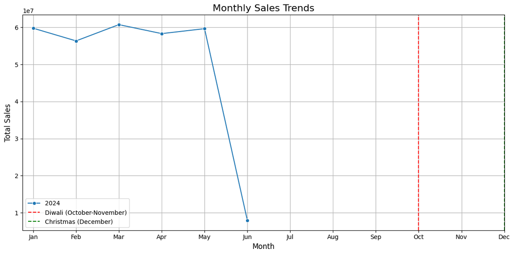

```python
import matplotlib.pyplot as plt
import seaborn as sns

# Assuming you already have your aggregated monthly sales data in the 'monthly_sales' DataFrame

# Step 1: Create a line plot for monthly sales trends
plt.figure(figsize=(12, 6))
sns.lineplot(x='Month', y='Total Sales', data=monthly_sales, marker='o', hue='Year', palette='tab10')

# Step 2: Customize plot
plt.title('Monthly Sales Trends', fontsize=16)
plt.xlabel('Month', fontsize=12)
plt.ylabel('Total Sales', fontsize=12)
plt.xticks(ticks=range(1, 13), labels=['Jan', 'Feb', 'Mar', 'Apr', 'May', 'Jun', 'Jul', 'Aug', 'Sep', 'Oct', 'Nov', 'Dec'])
plt.grid(True)

# Step 3: Highlight potential seasonal patterns (e.g., Diwali, Christmas, New Year)
# You can add vertical lines or annotate specific months to indicate festivals or holidays
plt.axvline(x=10, color='r', linestyle='--', label='Diwali (October-November)')
plt.axvline(x=12, color='g', linestyle='--', label='Christmas (December)')

# Optional: Add a legend
plt.legend()

# Step 4: Show the plot
plt.tight_layout()
plt.show()
```

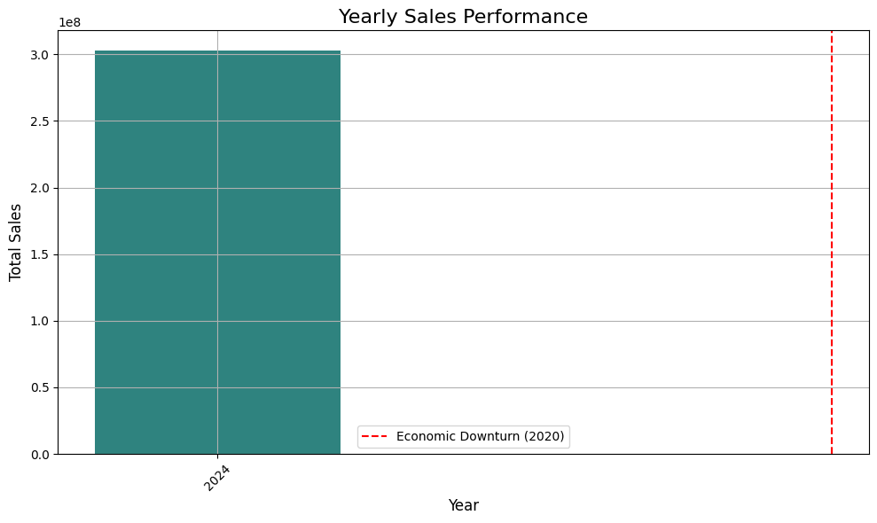

```
Yearly Sales Performance Summary:
   Year   Total Sales
0  2024  3.027927e+08

Year-on-Year Growth:
   Year  YoY Growth (%)
0  2024             NaN
```

```python
# Step 1: Aggregate total sales by year
yearly_sales = df.groupby('Year')['Total Sales'].sum().reset_index()

# Step 2: Plot Yearly Sales Performance
plt.figure(figsize=(10, 6))
sns.barplot(x='Year', y='Total Sales', data=yearly_sales, palette='viridis')

# Step 3: Customize Plot
plt.title('Yearly Sales Performance', fontsize=16)
plt.xlabel('Year', fontsize=12)
plt.ylabel('Total Sales', fontsize=12)
plt.xticks(rotation=45)
plt.grid(True)

# Optional: Highlight any specific years of interest (e.g., economic downturn, policy change)
# You can add annotations or vertical lines to mark key events
# Example: Highlight a specific year (e.g., 2020, if there was an economic downturn due to COVID-19)
plt.axvline(x=2, color='r', linestyle='--', label='Economic Downturn (2020)')

# Optional: Add a legend
plt.legend()

# Step 4: Show the plot
plt.tight_layout()
plt.show()

# Step 5: Summary Statistics for Yearly Sales
print("Yearly Sales Performance Summary:")
print(yearly_sales)

# Step 6: Calculate Year-on-Year Growth (optional)
yearly_sales['YoY Growth (%)'] = yearly_sales['Total Sales'].pct_change() * 100
print("\nYear-on-Year Growth:")
print(yearly_sales[['Year', 'YoY Growth (%)']])
```

Explanation: Yearly Sales Aggregation: The groupby('Year') function groups the data by year and sums the Total Sales for each year.

Bar Plot: The sns.barplot is used to create a bar chart to visually compare yearly sales. The x axis represents the years, and the y axis represents the total sales for each year.

Summary Statistics: The print statements display a summary of total yearly sales to track business growth over time.

Year-on-Year Growth: The pct_change() function calculates the percentage change in sales from year to year, allowing you to see whether the business is growing, stagnating, or declining.

```python
# Step 1: Identify Peak and Low Sales Periods
monthly_sales['Month_Name'] = monthly_sales['Month'].apply(lambda x: ['Jan', 'Feb', 'Mar', 'Apr', 'May', 'Jun', 'Jul', 'Aug', 'Sep', 'Oct', 'Nov', 'Dec'][x-1])

# Sort by total sales to find peak and low-performing months
peak_month = monthly_sales.loc[monthly_sales['Total Sales'].idxmax()]
low_month = monthly_sales.loc[monthly_sales['Total Sales'].idxmin()]

print(f"Peak Sales Month: {peak_month['Month_Name']} with Total Sales: {peak_month['Total Sales']}")
print(f"Low Sales Month: {low_month['Month_Name']} with Total Sales: {low_month['Total Sales']}")

# Step 2: Check if there are Returns or Cancellations
# Assuming there's a 'Returns' column and 'Cancellations' column in the dataset
if 'Returns' in df.columns and 'Cancellations' in df.columns:
    monthly_returns = df.groupby(['Year', 'Month'])['Returns'].sum().reset_index()
    monthly_cancellations = df.groupby(['Year', 'Month'])['Cancellations'].sum().reset_index()

    # Merge with monthly sales data to analyze the impact
    monthly_sales_returns = pd.merge(monthly_sales, monthly_returns, on=['Year', 'Month'])
    monthly_sales_cancellations = pd.merge(monthly_sales, monthly_cancellations, on=['Year', 'Month'])

    # Checking for high returns/cancellations during low sales months
    low_month_returns = monthly_sales_returns.loc[monthly_sales_returns['Month'] == low_month['Month']]
    low_month_cancellations = monthly_sales_cancellations.loc[monthly_sales_cancellations['Month'] == low_month['Month']]

    print(f"\nReturns and Cancellations in {low_month['Month_Name']} (Low Sales Month):")
    print(f"Returns: {low_month_returns['Returns'].values[0]}")
    print(f"Cancellations: {low_month_cancellations['Cancellations'].values[0]}")
else:
    print("\nNo Returns or Cancellations columns found in dataset.")
```

```
Peak Sales Month: Mar with Total Sales: 60750883.75
Low Sales Month: Jun with Total Sales: 7911581.62

No Returns or Cancellations columns found in dataset.
```

xplanation: Peak and Low Sales Periods:

We calculate the peak_month (the month with the highest sales) and low_month (the month with the lowest sales) by finding the maximum and minimum sales.

We also assign human-readable month names to make the output more intuitive.

Returns and Cancellations Impact:

If columns for Returns and Cancellations are present in the dataset, we group by year and month to analyze the total returns and cancellations for each month.

We merge these return and cancellation data with the monthly_sales data to see if there’s a correlation between low sales months and high returns or cancellations.

4️⃣ Suggested Strategies for Boosting Sales During Low-Performing Months: Here are a few strategies you can suggest based on low-performing months:

Seasonal Promotions: Offer special discounts during low-performing months to stimulate demand. For example, run "off-season" sales during summer months if winter is a high season.

Targeted Marketing Campaigns: Use email campaigns or social media to promote products that typically perform well in those months.

Flash Sales: Run limited-time offers or flash sales during these months to create urgency and drive purchases.

Bundling: Offer product bundles at a discounted rate to increase perceived value and drive more sales during slower months.

```python
import matplotlib.pyplot as plt
import seaborn as sns

# Assuming all necessary calculations (e.g., monthly_sales, yearly_sales) have already been done

# Step 1: Key Findings Summary
print("Key Findings on Sales Trends:")

# Monthly Sales Trends Summary
peak_month = monthly_sales.loc[monthly_sales['Total Sales'].idxmax()]
low_month = monthly_sales.loc[monthly_sales['Total Sales'].idxmin()]
print(f"Peak Sales Month: {peak_month['Month_Name']} with Total Sales: {peak_month['Total Sales']}")
print(f"Low Sales Month: {low_month['Month_Name']} with Total Sales: {low_month['Total Sales']}")

# Yearly Sales Performance
yearly_growth = yearly_sales[['Year', 'YoY Growth (%)']].dropna()  # Removing NaN values
print("\nYearly Sales Growth:")
print(yearly_growth)
```

```
Key Findings on Sales Trends:
Peak Sales Month: Mar with Total Sales: 60750883.75
Low Sales Month: Jun with Total Sales: 7911581.62

Yearly Sales Growth:
Empty DataFrame
Columns: [Year, YoY Growth (%)]
Index: []
```

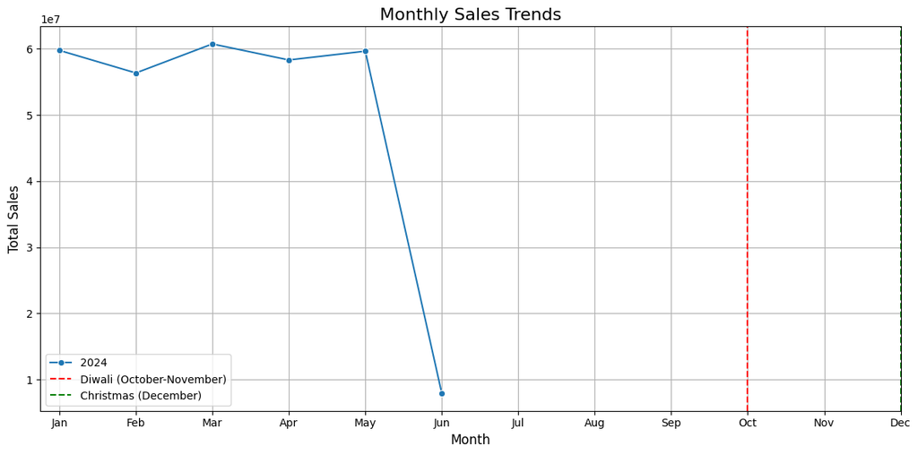

```python
# Step 2: Visualize Monthly Sales Trends
plt.figure(figsize=(12, 6))
sns.lineplot(x='Month', y='Total Sales', data=monthly_sales, marker='o', hue='Year', palette='tab10')
plt.title('Monthly Sales Trends', fontsize=16)
plt.xlabel('Month', fontsize=12)
plt.ylabel('Total Sales', fontsize=12)
plt.xticks(ticks=range(1, 13), labels=['Jan', 'Feb', 'Mar', 'Apr', 'May', 'Jun', 'Jul', 'Aug', 'Sep', 'Oct', 'Nov', 'Dec'])
plt.grid(True)
plt.axvline(x=10, color='r', linestyle='--', label='Diwali (October-November)')
plt.axvline(x=12, color='g', linestyle='--', label='Christmas (December)')
plt.legend()
plt.tight_layout()
plt.show()
```

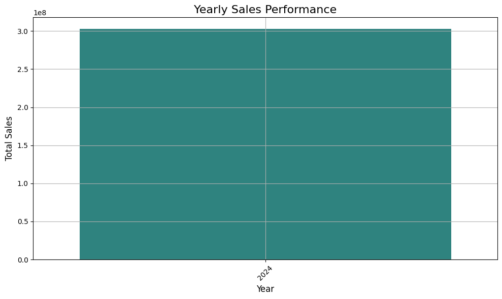

```python
# Step 3: Visualize Yearly Sales Performance (Bar Chart)
plt.figure(figsize=(10, 6))
sns.barplot(x='Year', y='Total Sales', data=yearly_sales, palette='viridis')
plt.title('Yearly Sales Performance', fontsize=16)
plt.xlabel('Year', fontsize=12)
plt.ylabel('Total Sales', fontsize=12)
plt.xticks(rotation=45)
plt.grid(True)
plt.tight_layout()
plt.show()
```